# Lab04

Ryleigh Landstra

2022-11-24

# Sentiment Analysis of Most Listened to Songs

##### The intention of this analysis is to attempt to use sentiment analysis on users’ 3 most listened to songs of all time and of the past month. For this lab I used my own music statistics from Spotify. I used the 3 most listened to songs of all time to gain an idea of the general sentiment of music I listen to overall. I then grabbed the 3 most listened to songs of the past month to compare.

**Read in necessary packages**

```r
library(tidyverse)
library(tidytext)
library(textdata)
```

**Download data**  
*Here I am downloading csv files containing the artist, track number, track line, and lyrics using the genius package. I combined them outside of Rstudio to create two datasets - one for my top 3 most listened to songs in the past month, and one of my top 3 most listened to songs of all time*

```r
# All Time Top 3 Songs
AllTime <- read.csv("C:/Users/rylan/Desktop/EAS 648/Lab04/AllTime.csv")
PastMonth <- read.csv("C:/Users/rylan/Desktop/EAS 648/Lab04/PastMonth.csv")
```

**Convert the data to tidy format**  
*Here I am taking my two datasets and converting the format to display one word per row*

```r
library(stringr)
## we need to make sure that the lyrics are characters
AllTime$lyric <- as.character(AllTime$lyric)
PastMonth$lyric <- as.character(PastMonth$lyric)

tidy_song_AT <- AllTime %>%
  group_by(track_title, level) %>%
  ungroup() %>%
  unnest_tokens(word,lyric)

tidy_song_PM <- PastMonth %>%
  group_by(track_title, level) %>%
  ungroup() %>%
  unnest_tokens(word,lyric)
```

**Apply the Bing et al method to each dataset**  
*Here I am using the Bing method to identify the overall sentiment of the 3 songs in each dataset and plotting it using ggplot*

```r
AT_sentiment <- tidy_song_AT %>%
  inner_join(get_sentiments("bing")) %>%
  count(track_title, index = line, sentiment) %>%
  spread(sentiment, n, fill = 0) %>%
  mutate(sentiment = positive - negative)
```

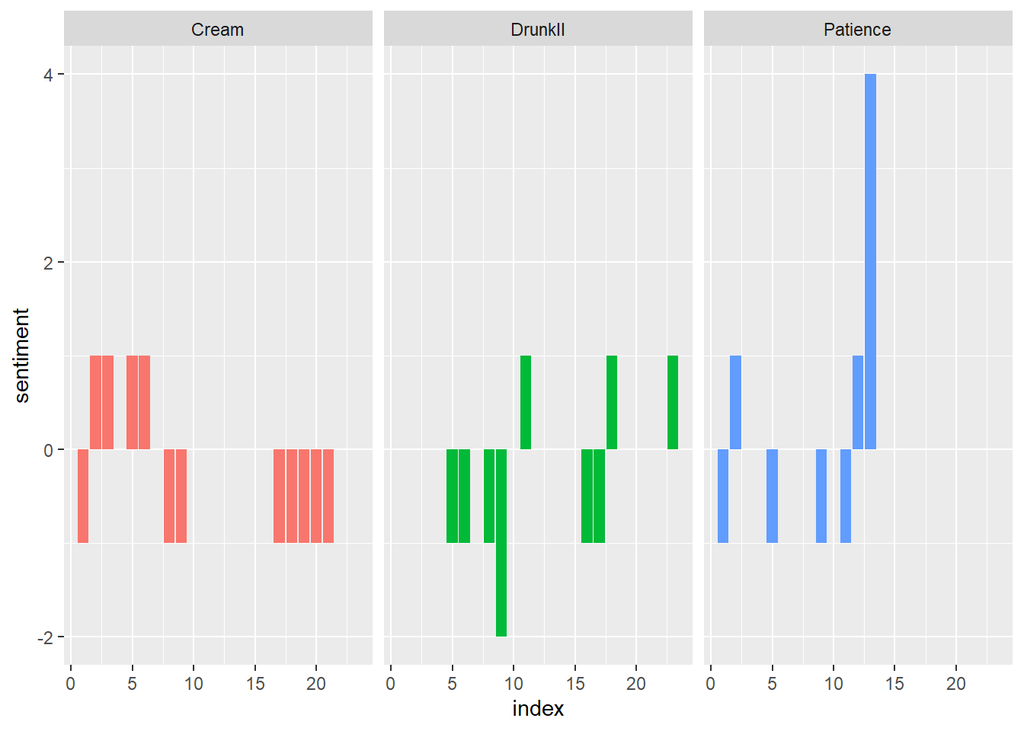

```r
ggplot(AT_sentiment, aes(index, sentiment, fill = track_title)) +
  geom_col(show.legend = FALSE) +
  facet_wrap(~track_title)
```

```r
PM_sentiment <- tidy_song_PM %>%
  inner_join(get_sentiments("bing")) %>%
  count(track_title, index = line, sentiment) %>%
  spread(sentiment, n, fill = 0) %>%
  mutate(sentiment = positive - negative)
```

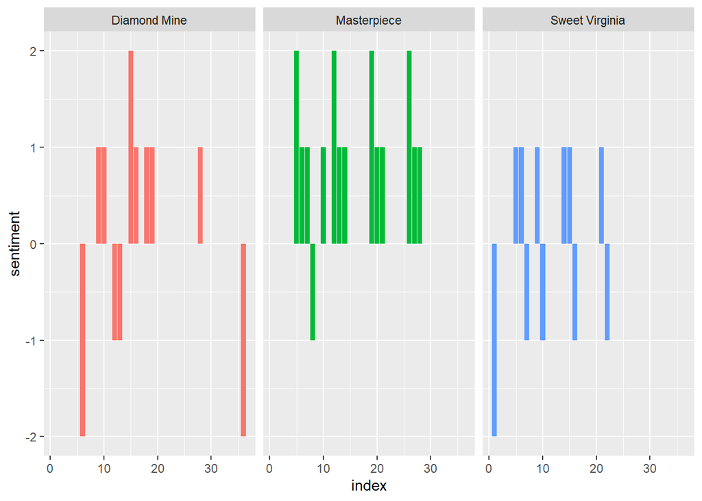

```r
ggplot(PM_sentiment, aes(index, sentiment, fill = track_title)) +
  geom_col(show.legend = FALSE) +
  facet_wrap(~track_title)
```

**Combine results for better comparison**  
*Here I am creating a column to categorize the datasets*

```r
PM_bing <- PM_sentiment %>%
  mutate(method = 'Past Month')

AT_bing <- AT_sentiment %>%
  mutate(method = 'All Time')
```

*And then using the new objects to combine the data into two plots to compare the sentiments of my top 3 songs of all time vs the past month*

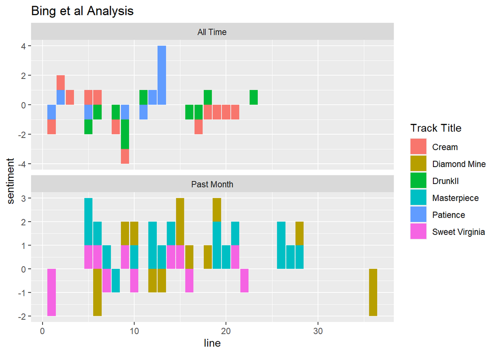

```r
combined_bing <- bind_rows(PM_bing,
          AT_bing) %>%
  ggplot(aes(index, sentiment, fill = track_title)) +
  ggtitle("Bing et al Analysis") +
  geom_col(show.legend = TRUE) +
  facet_wrap(~method, ncol = 1, scales = "free_y")
combined_bing + labs(fill = "Track Title", x = "line")
```

*We can also sum the overall sentiment score of the bing method from the two datasets. These results show that my top 3 most played songs of the past month as significantly more positive than that of my all time more listened to songs*

```r
sum(AT_sentiment$sentiment)
```

```
## [1] -6
```

```r
sum(PM_sentiment$sentiment)
```

```
## [1] 18
```

*The results here show that the songs I’ve listened to in the past month are significantly more ‘positive’ than the sentiment of music I listen to overall*  
**Evaluate words contributing to positive and negative sentiments**  
*Here I am creating plots of each data set that show the counts of words that are contributing to the overall sentiment scores*

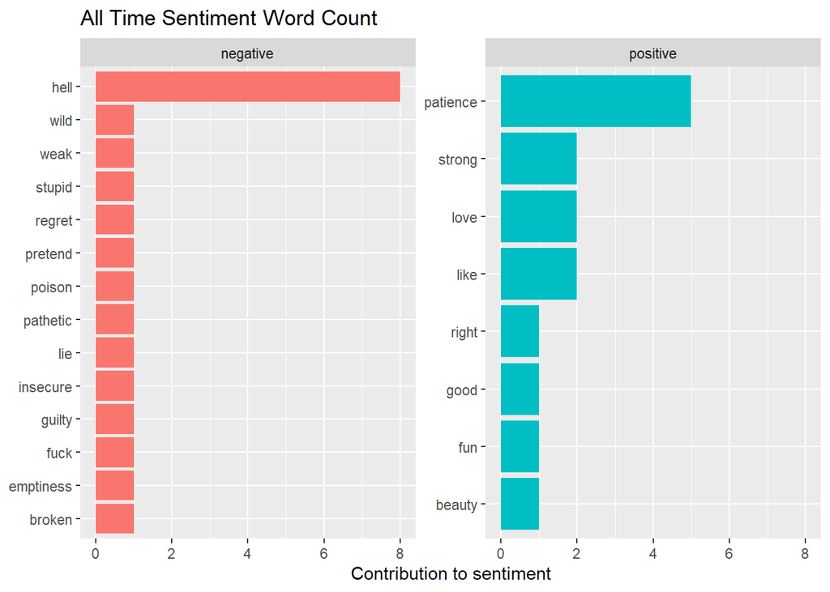

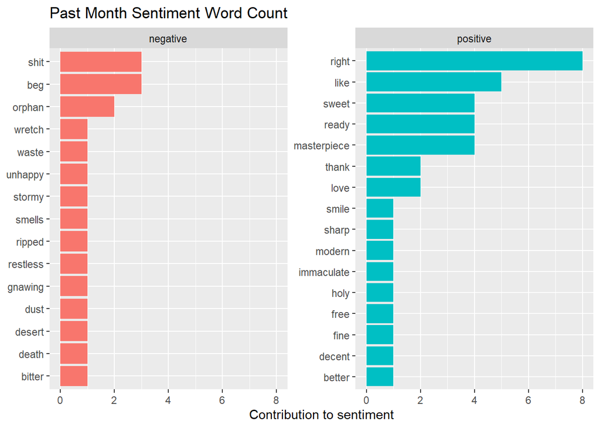

```r
bing_word_counts_AT <- tidy_song_AT %>%
  inner_join(get_sentiments("bing")) %>%
  count(word, sentiment, sort = TRUE) %>%
  ungroup()

bing_word_counts_PM <- tidy_song_PM %>%
  inner_join(get_sentiments("bing")) %>%
  count(word, sentiment, sort = TRUE) %>%
  ungroup()

AT_countp <- bing_word_counts_AT %>%
  group_by(sentiment) %>%
  top_n(10) %>%
  ungroup() %>%
  mutate(word = reorder(word, n)) %>%
  ggplot(aes(word, n, fill = sentiment)) +
  geom_col(show.legend = FALSE) +
  ggtitle("All Time Sentiment Word Count") +
  facet_wrap(~sentiment, scales = "free_y") +
  labs(y = "Contribution to sentiment",
       x = NULL) +
  coord_flip()

PM_countp <- bing_word_counts_PM %>%
  group_by(sentiment) %>%
  top_n(10) %>%
  ungroup() %>%
  mutate(word = reorder(word, n)) %>%
  ggplot(aes(word, n, fill = sentiment)) +
  ggtitle("Past Month Sentiment Word Count") +
  geom_col(show.legend = FALSE) +
  facet_wrap(~sentiment, scales = "free_y") +
  labs(y = "Contribution to sentiment",
       x = NULL) +
  coord_flip()
```

*In the ‘All Time’ data, we see that the words ‘patience’ and ‘strong’ contribute to the positive sentiment. But, reading the lyrics of the song ‘Patience’, we can understand that the context of these words actually do not have positive associations - they are being said in a somewhat sarcastic way. In the ‘Past Month’ data, we see that the words ‘right’ and ‘like’ have high counts in the positive chart. Both of these words alone do not necessarily have positive or negative connotations, and need context to determine sentiment*

**Use the Sentimentr package to account for polarity and context of lyrics**  
*Here I would like to compare the bing method to the sentimentr package since my total results of sentiment were significantly different between the two datasets (-6 vs +18)*

```r
library(sentimentr)

song_sentiment_AT <- AllTime %>%
    get_sentences() %>%
    sentiment_by(by = c('track_title', 'line')) %>%
  as.data.frame()
```

```r
song_sentiment_PM <- PastMonth %>%
    get_sentences() %>%
    sentiment_by(by = c('track_title', 'line')) %>%
  as.data.frame()
```

*We can now plot these results to compare to the bing analysis*

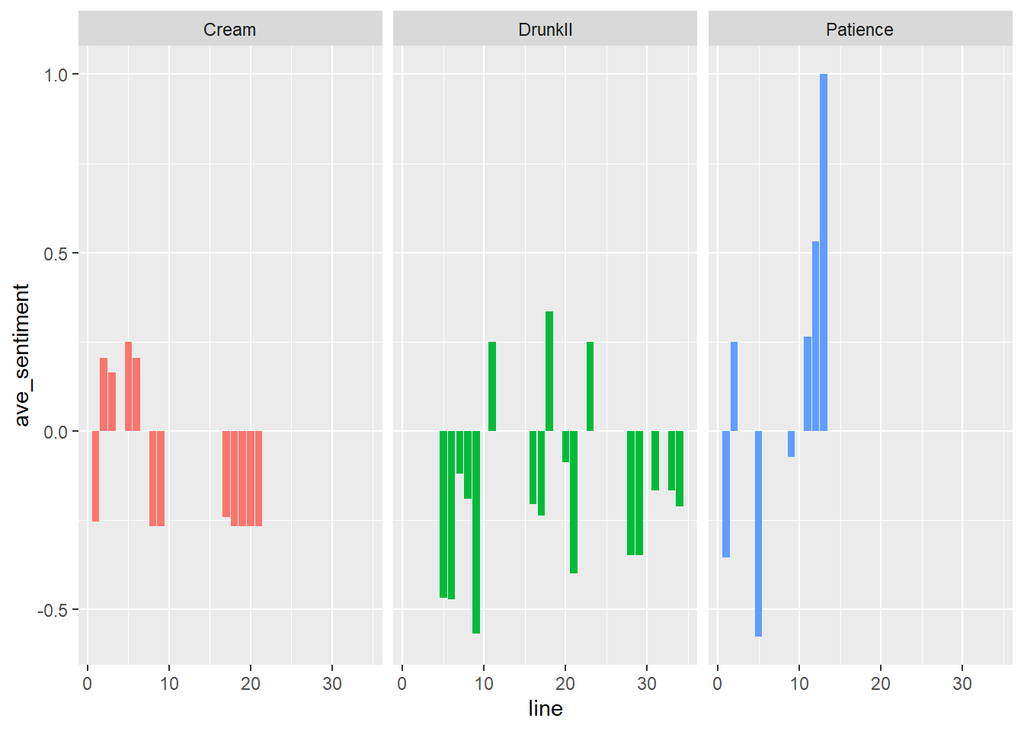

```r
ggplot(song_sentiment_AT, aes(line, ave_sentiment, fill = track_title)) +
  geom_col(show.legend = FALSE) +
  facet_wrap(~track_title)
```

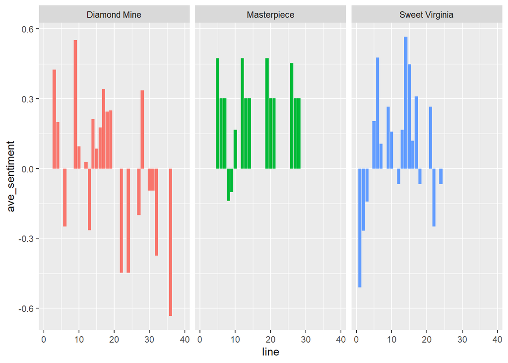

```r
 ggplot(song_sentiment_PM, aes(line, ave_sentiment, fill = track_title)) +
  geom_col(show.legend = FALSE) +
  facet_wrap(~track_title)
```

*Again, I’d like to see these two graphs in a way that is easier to compare the results*

```r
PM_sent <- song_sentiment_PM %>%
  mutate(method = 'Past Month')

AT_sent <- song_sentiment_AT %>%
  mutate(method = 'All Time')
```

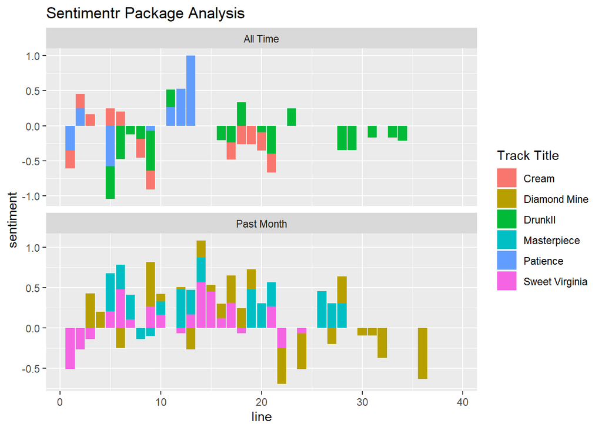

```r
combined_sent <- bind_rows(PM_sent,
          AT_sent) %>%
  ggplot(aes(line, ave_sentiment, fill = track_title)) +
  ggtitle("Sentimentr Package Analysis")+
  geom_col(show.legend = TRUE) +
  facet_wrap(~method, ncol = 1, scales = "free_y")
combined_sent + labs(fill = "Track Title", y = "sentiment")
```

*We can then sum these two results*

```r
sum(song_sentiment_AT$ave_sentiment)
```

```
## [1] -3.380095
```

```r
sum(song_sentiment_PM$ave_sentiment)
```

```
## [1] 6.075932
```

*As we can see, the difference between the bing method and the sentimentr method are noticeable. The All Time songs are a bit less negative, while the Past Month songs are a lot less positive.*

**Here are the two end plots next to each other for easier comparison of the Bing et al method and the sentimentr method**

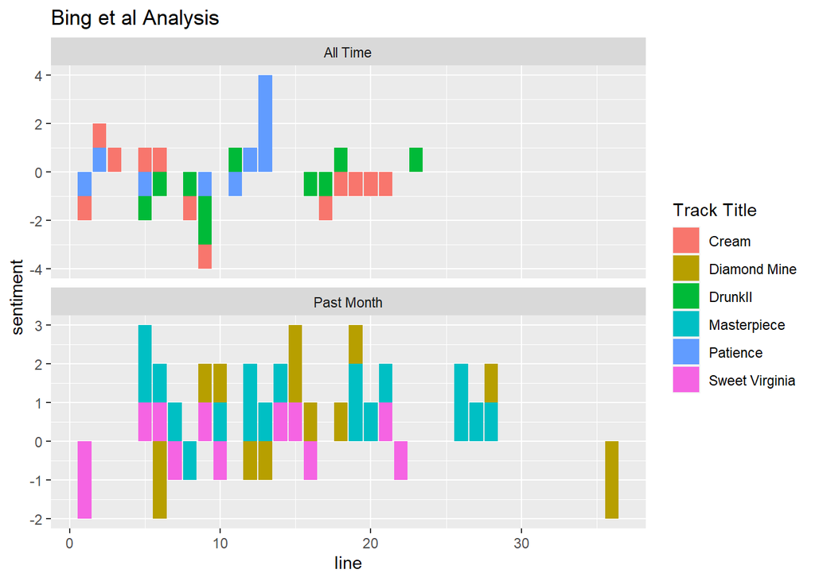

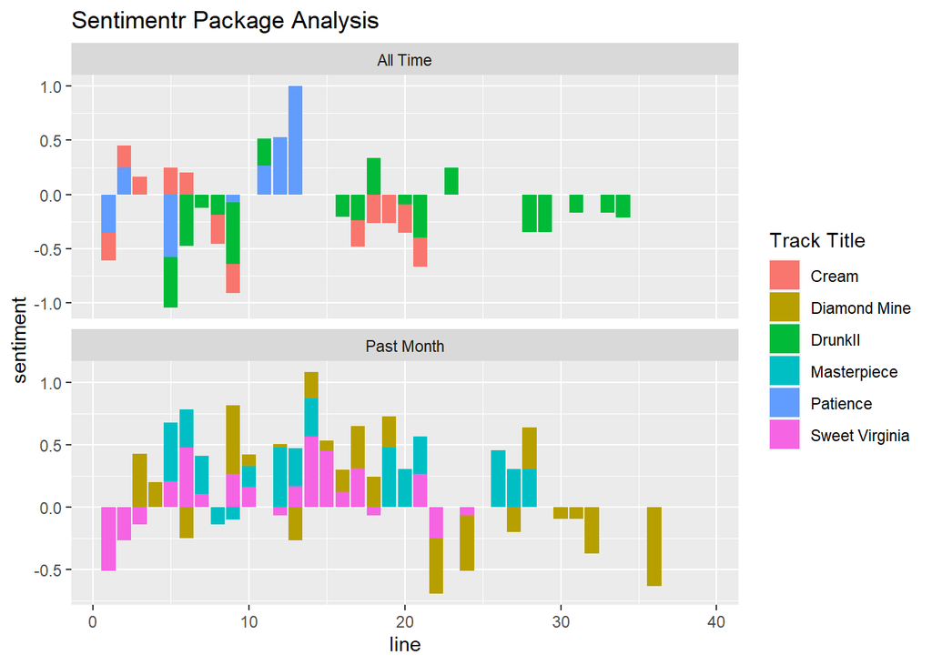

*Having had listened to these songs, I generally agree with the results. I think the sentimentr method is more accurate in the sentiment analysis of the songs. For instance, the song ‘Diamond Mine’ shows more negative sentiment in the second half of the song in the sentimentr analysis than in the bing analysis, where there was only one negatively associated word. Knowing this song, I would associate the second half in particular as having more ‘negative’ lyrics. In general, it looks like the sentimentr package is able to analyze and detect more sentiments in lyrics, rather than relying on single words with no context to measure sentiment*